# Uber Clustering and Forecasting

# 1. Library installation

```r
##install.packages("factoextra")
##install.packages("cluster")
##install.packages("fpc")
##install.packages("mclust")
##install.packages("dplyr")
##install.packages("ggplot2")
##install.packages("forecast")

library(factoextra)
library(cluster)
library(fpc)
library(mclust)
library(dplyr)
library(ggplot2)
library(forecast)
```

# 2. Read and sampling data

```r
uber <- read.csv("data/uber-data.csv")

str(uber)
```

```
'data.frame':   1028136 obs. of  4 variables:
 $ Date.Time: chr  "9/1/2014 0:01:00" "9/1/2014 0:01:00" "9/1/2014 0:03:00" "9/1/2014 0:06:00" ...
 $ Lat      : num  40.2 40.8 40.8 40.7 40.8 ...
 $ Lon      : num  -74 -74 -74 -74 -73.9 ...
 $ Base     : chr  "B02512" "B02512" "B02512" "B02512" ...
```

```r
summary(uber)
```

```
     Date.Time            Lat             Lon                Base
 Length   :1028136   Min.   :39.99   Min.   :-74.77   Length   :1028136
 N.unique :  42907   1st Qu.:40.72   1st Qu.:-74.00   N.unique :      5
 N.blank  :      0   Median :40.74   Median :-73.98   N.blank  :      0
 Min.nchar:     16   Mean   :40.74   Mean   :-73.97   Min.nchar:      6
 Max.nchar:     18   3rd Qu.:40.76   3rd Qu.:-73.96   Max.nchar:      6
                     Max.   :41.35   Max.   :-72.72
```

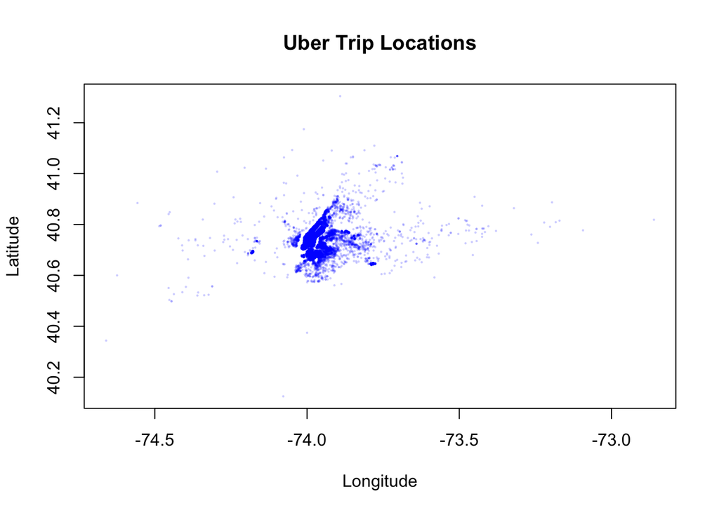

```r
# Select 30,000 trips for analysis
set.seed(42)
sample_idx <- sample(nrow(uber), 30000)

uber_sample <- uber[sample_idx, ]

# Coordinates used for clustering
coords <- uber_sample[, c("Lon", "Lat")]

# Approximate conversion from degrees to km
lat0 <- mean(coords$Lat) * pi / 180

coords_km <- data.frame(
  x = (coords$Lon - mean(coords$Lon)) *
    111.32 * cos(lat0),
  y = (coords$Lat - mean(coords$Lat)) *
    111.32
)

# Geographical scatter plot
plot(
  coords$Lon, coords$Lat,
  pch = 16,
  cex = 0.3,
  col = rgb(0, 0, 1, 0.2),
  xlab = "Longitude",
  ylab = "Latitude",
  main = "Uber Trip Locations"
)
```

# 3. Hopkins statistics

We can see that our data is clusterable since we got the result.

```r
hop <- get_clust_tendency(
  coords_km,
  n = 300,
  graph = FALSE,
  seed = 42
)
hop$hopkins_stat
```

```
[1] 0.9977638
```

# 4. Optimal k(clusters) using K-means,Calinski-Harabasz and Gap statistics

## 4.1 Silhouette index + Calinski-Harabasz

```r
set.seed(42)
sil_idx <- sample(nrow(coords_km), 2000)
sil_dist <- dist(coords_km[sil_idx, ])

results <- data.frame(
  k = 2:15,
  km_sil = NA_real_, km_ch = NA_real_,
  clara_sil = NA_real_, clara_ch = NA_real_
)

set.seed(42)

for (i in seq_along(results$k)) {

  k <- results$k[i]

  km <- kmeans(coords_km, centers = k, nstart = 25)

  cl <- clara(coords_km, k = k,
              samples = 20, sampsize = 1000,
              rngR = TRUE)

  results[i, 2:5] <- c(
    mean(silhouette(km$cluster[sil_idx], sil_dist)[, "sil_width"]),
    calinhara(coords_km, km$cluster),
    mean(silhouette(cl$clustering[sil_idx], sil_dist)[, "sil_width"]),
    calinhara(coords_km, cl$clustering)
  )
}
round(results, 3)
```

```
    k km_sil    km_ch clara_sil  clara_ch
1   2  0.679 12971.37     0.336  8867.483
2   3  0.392 14923.57     0.390 14758.656
3   4  0.411 14440.36     0.372 13295.076
4   5  0.430 15093.32     0.338 12679.174
5   6  0.435 15990.37     0.358 12238.221
6   7  0.455 17047.60     0.292 10907.603
7   8  0.463 18679.76     0.329 13086.712
8   9  0.434 19074.14     0.355 12879.982
9  10  0.453 19568.94     0.380 14921.005
10 11  0.449 20533.97     0.336 13893.698
11 12  0.399 20347.75     0.366 12992.400
12 13  0.404 20352.69     0.354 12462.471
13 14  0.402 19847.17     0.352 11984.442
14 15  0.411 20105.22     0.369 14725.360
```

## 4.2 Graphical comparison

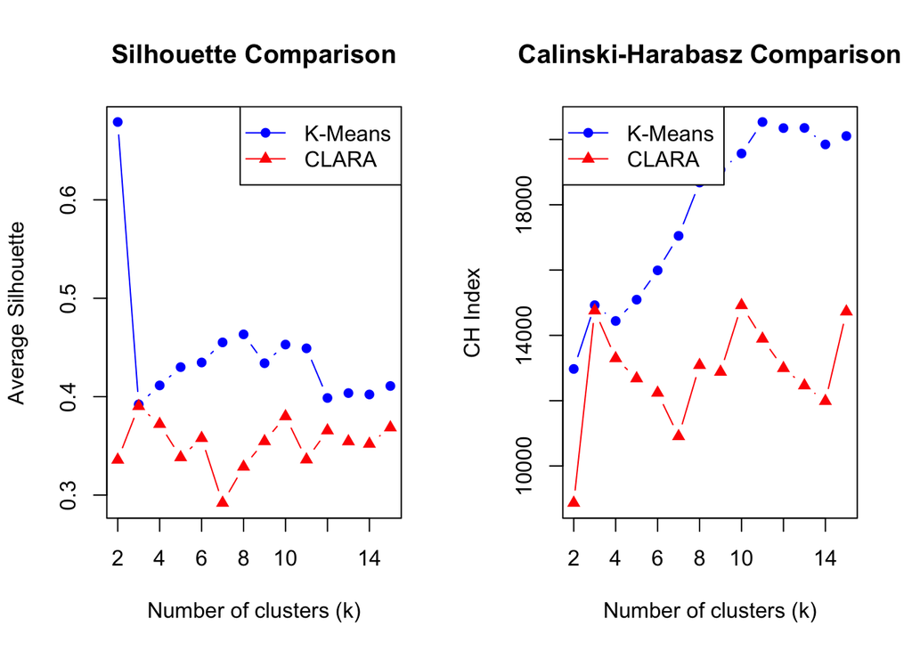

```r
par(mfrow = c(1, 2))

matplot(results$k, results[, c("km_sil", "clara_sil")],
        type = "b", pch = c(16, 17), lty = 1,
        col = c("blue", "red"),
        xlab = "Number of clusters (k)",
        ylab = "Average Silhouette",
        main = "Silhouette Comparison")

legend("topright", c("K-Means", "CLARA"),
       col = c("blue", "red"), pch = c(16, 17), lty = 1)

matplot(results$k, results[, c("km_ch", "clara_ch")],
        type = "b", pch = c(16, 17), lty = 1,
        col = c("blue", "red"),
        xlab = "Number of clusters (k)",
        ylab = "CH Index",
        main = "Calinski-Harabasz Comparison")

legend("topleft", c("K-Means", "CLARA"),
       col = c("blue", "red"), pch = c(16, 17), lty = 1)
```

```r
par(mfrow = c(1, 1))
```

## 4.3 Gap statistics

[output not shown]

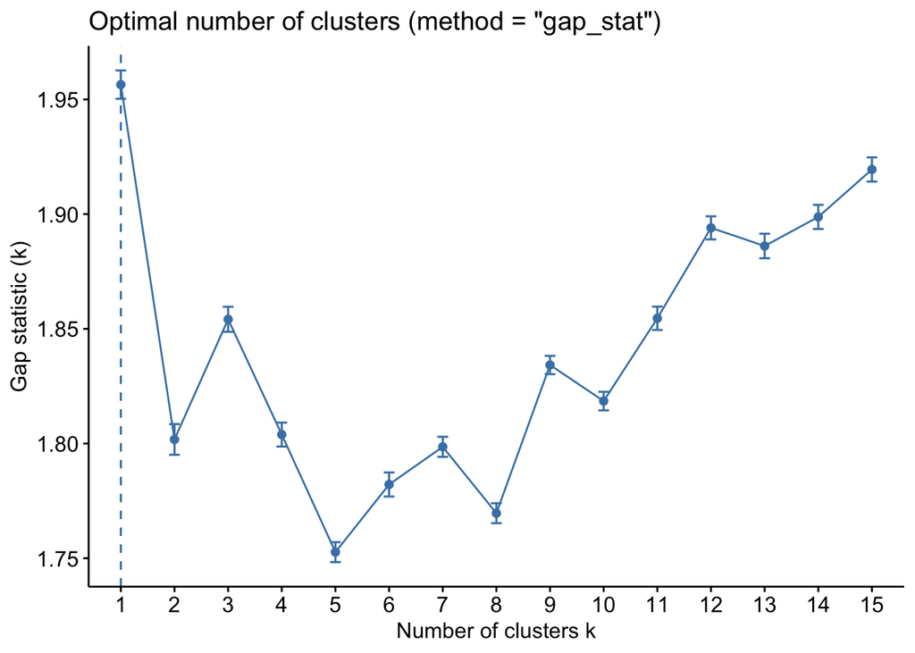

```r
set.seed(42)
coords_gap <- coords_km[sample(nrow(coords_km), 3000), ]

set.seed(42)
fviz_nbclust(coords_gap, kmeans,
             method = "gap_stat",
             k.max = 15, nboot = 50,
             nstart = 25)
```

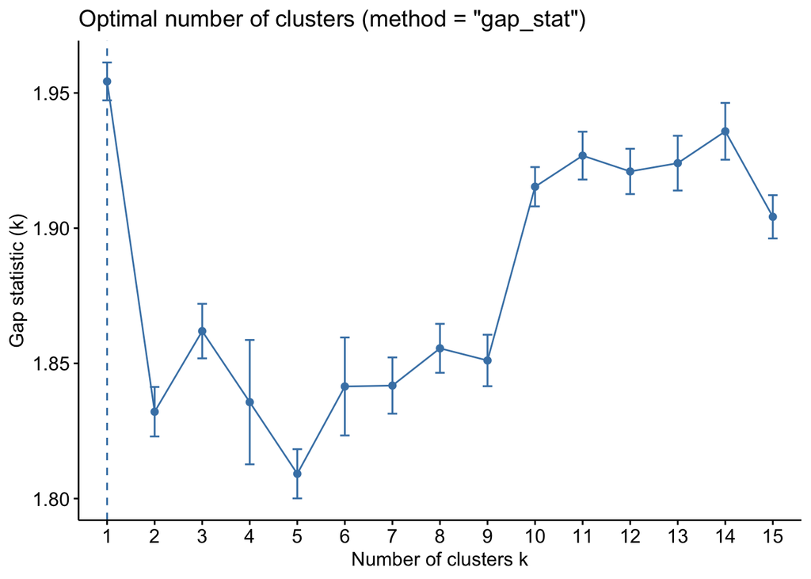

```r
set.seed(42)
fviz_nbclust(
  coords_gap,
  cluster::clara,
  method = "gap_stat",
  k.max = 15,
  nboot = 10,
  samples = 5,
  sampsize = 300,
  rngR = TRUE
)
```

# 5. Evaluation of K-means and CLARA

Analysing the whole statistics and methods I prefer to stick with 3 numbers of cluters and evaluate those algorithms for k = 3.

```r
k_final <- 3

# k-means evaluation
set.seed(42)
km_final <- kmeans(
  coords_km,
  centers = k_final,
  nstart = 25
)

# clara evaluation
set.seed(42)
clara_final <- clara(
  coords_km,
  k = k_final,
  samples = 20,
  sampsize = 1000,
  rngR = TRUE
)

# size of clusters that we done
table(km_final$cluster)
```

```
    1     2     3
12543 16267  1190
```

```r
table(clara_final$clustering)
```

```
    1     2     3
14988 13891  1121
```

```r
# how many percentage clusters took from overall sample
round(prop.table(table(km_final$cluster)) * 100, 2)
```

```
    1     2     3
41.81 54.22  3.97
```

```r
round(prop.table(table(clara_final$clustering)) * 100, 2)
```

```
    1     2     3
49.96 46.30  3.74
```

```r
# check centroids and medoids
round(km_final$centers, 2)
```

```
      x     y
1  0.77  3.57
2 -1.81 -2.26
3 16.63 -6.67
```

```r
round(clara_final$medoids, 2)
```

```
         x      y
[1,] -1.90  -1.66
[2,] -0.28   2.57
[3,] 15.95 -10.54
```

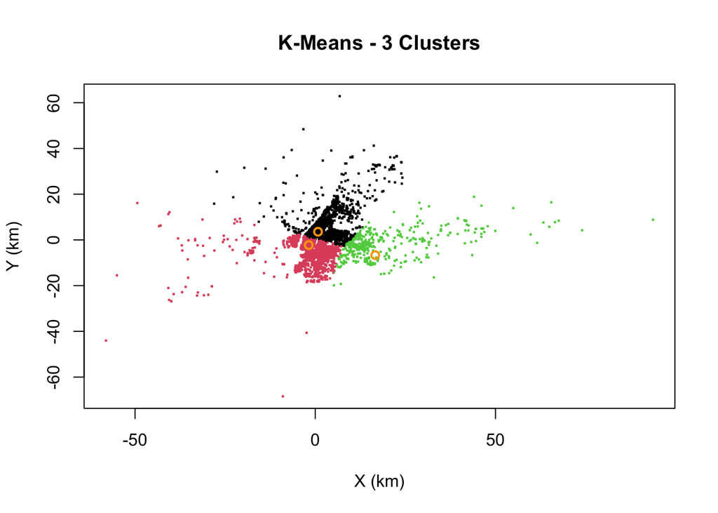

```r
# k-mean plot
plot(coords_km, col = km_final$cluster,
     pch = 15, cex = 0.3,
     main = "K-Means - 3 Clusters",
     xlab = "X (km)", ylab = "Y (km)")

points(km_final$centers, pch = 1,
       cex = 1, lwd = 2, col = "orange")
```

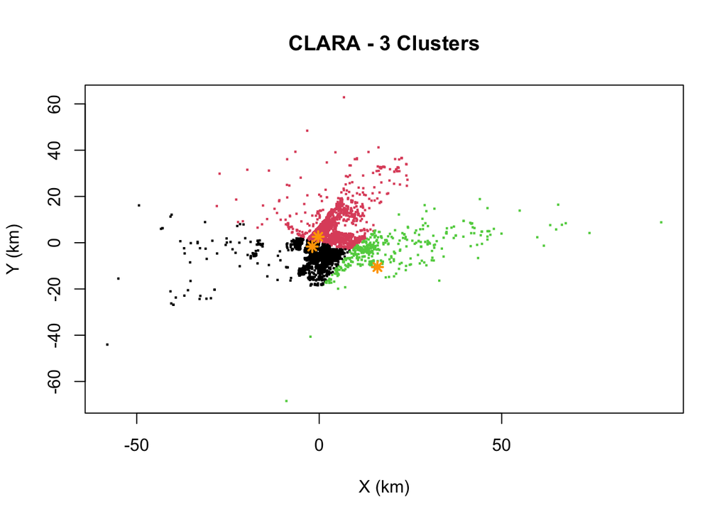

```r
# CLARA plot
plot(coords_km, col = clara_final$clustering,
     pch = 15, cex = 0.3,
     main = "CLARA - 3 Clusters",
     xlab = "X (km)", ylab = "Y (km)")

points(clara_final$medoids, pch = 8,
       cex = 1, lwd = 2, col = "orange")
```

```r
# cluster assignments for later analysis
uber_sample$km_cluster <- km_final$cluster
uber_sample$clara_cluster <- clara_final$clustering
```

# 6. Comparing both solution using Adjusted Rand Index

I would like to compare both algorithms that we used before CLARA and K-means to see either they are agree or not with each other and after that move to comparison analysis of those clusters that we already made. (so far - clear no need any additional comments, suppose so)

```r
ari <- adjustedRandIndex(
  km_final$cluster,
  clara_final$clustering
)

round(ari, 3)
```

```
[1] 0.837
```

# 7. Analyse clusters by time

Since we already compare ARI and got positive results from that point I would like to take K-mean as our primary clustering method for subsequent temporal analysis and demand forecasting. This avoids redundant analyses of substantially similar cluster structures while maintaining a consistent geographical segmentation throughout the remaining study.

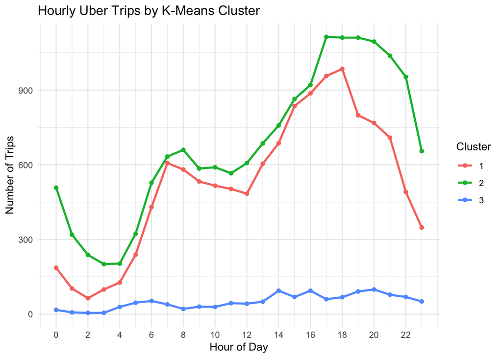

```r
# timestamps to New York time
uber_sample$datetime <- as.POSIXct(
  uber_sample$Date.Time,
  format = "%m/%d/%Y %H:%M:%S",
  tz = "America/New_York"
)

# take hours from date
uber_sample$hour <- as.integer(
  format(uber_sample$datetime, "%H")
)

# hourly activity and geographical center
hourly_centers <- uber_sample %>%
  group_by(km_cluster, hour) %>%
  summarise(
    trips = n(),
    center_lon = mean(Lon),
    center_lat = mean(Lat),
    .groups = "drop"
  )

# hourly trip activity visualisation graph
ggplot(hourly_centers,
       aes(x = hour, y = trips,
           color = factor(km_cluster))) +
  geom_line(linewidth = 1) +
  geom_point(size = 1.5) +
  scale_x_continuous(breaks = seq(0, 23, 2)) +
  labs(
    title = "Hourly Uber Trips by K-Means Cluster",
    x = "Hour of Day",
    y = "Number of Trips",
    color = "Cluster"
  ) +
  theme_minimal()
```

**Cluster 1:** Pickup activity increases during the afternoon,between 13:00 and 18:00, reaching its peak around 18:00. Also, demand decreases throughout the evening.

**Cluster 2:** This cluster has the highest number of pickups. Activity increases significantly during the afternoon and reaches its highest levels between 17:00 and 20:00. Relatively high activity is also observed around midnight, potentially reflecting nightlife or other late-night transportation demand.

**Cluster 3:** This cluster has substantially lower pickup activity compared with the other two clusters. Although the absolute fluctuations are smaller, activity still varies throughout the day, with particularly low demand during early morning hours and modest increases in the afternoon and evening.

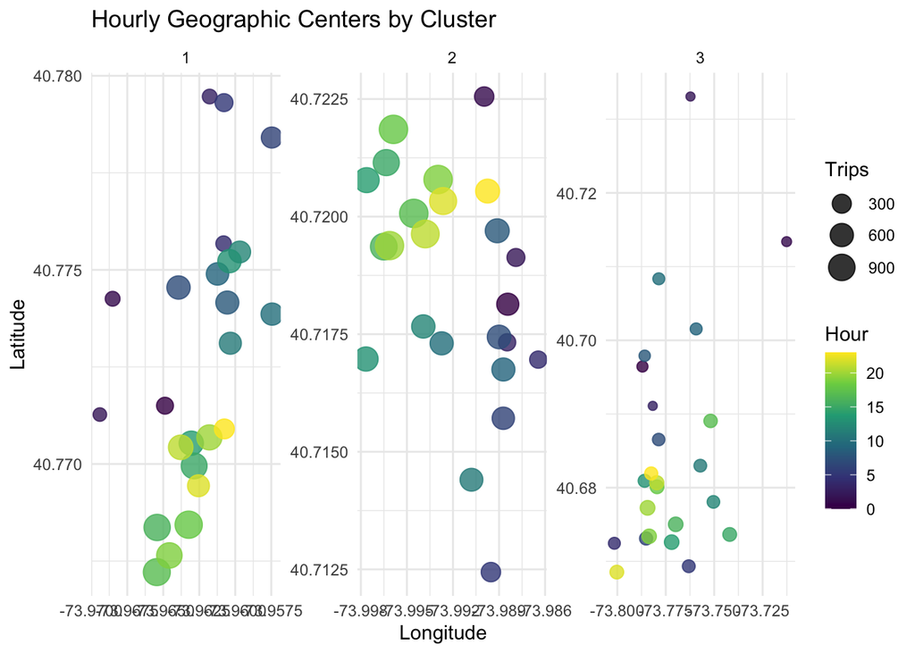

```r
# hourly geographic centers graph
ggplot(hourly_centers,
       aes(x = center_lon, y = center_lat)) +
  geom_point(
    aes(color = hour, size = trips),
    alpha = 0.8
  ) +
  facet_wrap(~ km_cluster, scales = "free") +
  scale_color_viridis_c() +
  scale_size(range = c(2, 7)) +
  labs(
    title = "Hourly Geographic Centers by Cluster",
    x = "Longitude",
    y = "Latitude",
    color = "Hour",
    size = "Trips"
  ) +
  theme_minimal()
```

**Cluster 1** shows some variation in its north–south geographical center, with several afternoon and evening hours associated with more southerly average pickup locations. **Cluster 2** mostly concentrated hourly centers, suggesting that its geographical demand distribution remains relatively consistent throughout the day. **Cluster 3** shows greater dispersion of hourly centers. However, this cluster contains considerably fewer pickups, meaning that its hourly geographical averages may be more sensitive to individual observations and outliers. So Uber pickup activity changes not only in volume but also in its geographical concentration throughout the day.

# 8. Cluster analysis by date

```r
# date by new york time
uber_sample$date <- as.Date(
  uber_sample$datetime,
  tz = "America/New_York"
)

# date range
range(uber_sample$date)
```

```
[1] "2014-09-01" "2014-09-30"
```

```r
# calculate daily trip counts and geographical centers
daily_centers <- uber_sample %>%
  group_by(km_cluster, date) %>%
  summarise(
    trips = n(),
    center_lon = mean(Lon),
    center_lat = mean(Lat),
    .groups = "drop"
  )
```

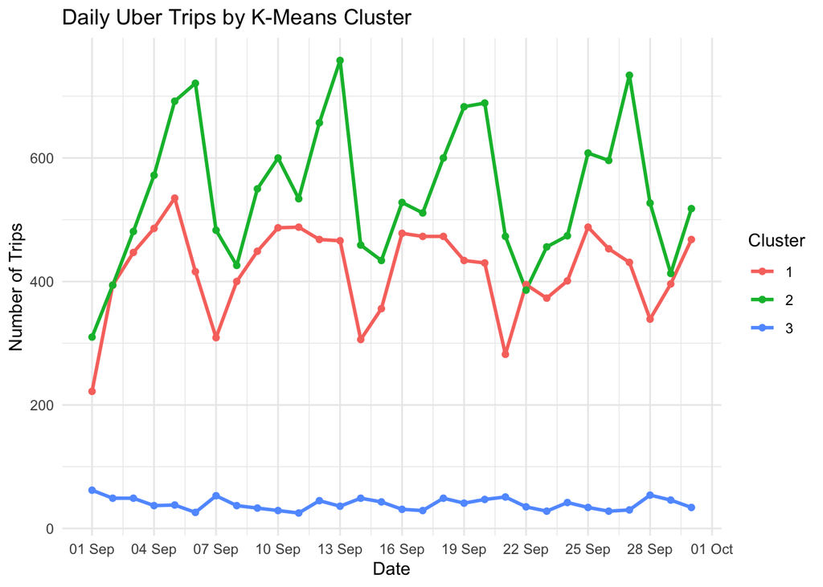

```r
ggplot(daily_centers,
       aes(x = date, y = trips,
           color = factor(km_cluster))) +
  geom_line(linewidth = 1) +
  geom_point(size = 1.5) +
  scale_x_date(date_breaks = "3 days",
               date_labels = "%d %b") +
  labs(
    title = "Daily Uber Trips by K-Means Cluster",
    x = "Date",
    y = "Number of Trips",
    color = "Cluster"
  ) +
  theme_minimal()
```

**Cluster 2:** This cluster has the highest daily pickup volume and exhibits a more pronounced weekly pattern. Significant peaks occur on Saturdays, suggesting that weekend activity plays an important role in the geographical region represented by this cluster.(also showed pattern of a seasonality on a graph)

**Cluster 3:** Daily pickup activity remains lower, with relatively small absolute fluctuations and no clearly identifiable weekly pattern.

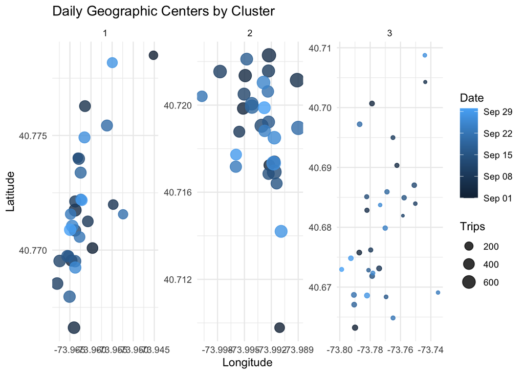

```r
ggplot(daily_centers,
       aes(x = center_lon, y = center_lat)) +
  geom_point(
    aes(color = date, size = trips),
    alpha = 0.8
  ) +
  facet_wrap(~ km_cluster, scales = "free") +
  labs(
    title = "Daily Geographic Centers by Cluster",
    x = "Longitude",
    y = "Latitude",
    color = "Date",
    size = "Trips"
  ) +
  theme_minimal()
```

**Cluster 1** is relatively compact and generally located in the more northern part of the area. In the same time some daily movement is visible, most daily centers remain concentrated within a region.

**Cluster 2** is also geographically concentrated, but its daily centers are located farther south than those of Cluster 1. The cluster shows relatively stable spatial behaviour during the month, with only limited day-to-day movement.

**Cluster 3** - the greatest spatial dispersion. Its daily centers fluctuate more strongly across the month, covering a wider range of locations. Since this cluster contains substantially fewer trips, its daily average location is more sensitive to individual observations and outliers.

# 9. Forecasting

First of all we need to prepare our data for forecasting

```r
# 2014 september dates
dates <- seq(
  as.Date("2014-09-01"),
  as.Date("2014-09-30"),
  by = "day"
)

# daily trip counts for each K-Means cluster
daily_counts <- table(
  factor(uber_sample$date, levels = dates),
  factor(uber_sample$km_cluster, levels = 1:3)
)


# descriptive statistics
cluster_summary <- data.frame(
  Cluster = 1:3,
  Mean_Daily = round(colMeans(daily_counts), 2),
  SD_Daily = round(apply(daily_counts, 2, sd), 2),
  Min_Daily = apply(daily_counts, 2, min),
  Max_Daily = apply(daily_counts, 2, max),
  CV = round(
    100 * apply(daily_counts, 2, sd) /
      colMeans(daily_counts),
    2
  )
)

print(cluster_summary)
```

```
  Cluster Mean_Daily SD_Daily Min_Daily Max_Daily    CV
1       1     418.10    71.70       222       535 17.15
2       2     542.23   114.84       310       758 21.18
3       3      39.67     9.70        25        62 24.46
```

```r
# function for mean abs error
mae <- function(actual, predicted) {
  mean(abs(actual - as.numeric(predicted)))
}

# prepare storage for result
results_mae <- data.frame(
  Cluster = 1:3,
  Naive = NA_real_,
  Seasonal_Naive = NA_real_,
  ETS = NA_real_,
  ARIMA = NA_real_
)

trains <- vector("list", 3)
fits <- vector("list", 3)
predictions <- vector("list", 3)

for (cl in 1:3) {

  # daily trip counts
  trips <- as.numeric(daily_counts[, cl])

  # training September 1-23 (23 days)
  train <- ts(trips[1:23], frequency = 7)

  # testing September 24-30 (7 days)
  test <- trips[24:30]

  # naive forecasting
  f_naive <- naive(train, h = 7)

  # seasonal naive forecasting
  f_snaive <- snaive(train, h = 7)

  # exponential smoothing
  fit_ets <- forecast::ets(train)
  f_ets <- forecast::forecast(fit_ets, h = 7)

  # ARIMA forecasting
  fit_arima <- forecast::auto.arima(train, seasonal = TRUE)
  f_arima <- forecast::forecast(fit_arima, h = 7)

  # Calculate MAE for all four methods
  results_mae[cl, 2:5] <- c(
    mae(test, f_naive$mean),
    mae(test, f_snaive$mean),
    mae(test, f_ets$mean),
    mae(test, f_arima$mean)
  )

  # save training data
  trains[[cl]] <- train

  # save fitted models
  fits[[cl]] <- list(
    Naive = f_naive,
    Seasonal_Naive = f_snaive,
    ETS = fit_ets,
    ARIMA = fit_arima
  )

  # save actual values and forecasts
  predictions[[cl]] <- data.frame(
    Date = dates[24:30],
    Actual = test,
    Naive = as.numeric(f_naive$mean),
    Seasonal_Naive = as.numeric(f_snaive$mean),
    ETS = as.numeric(f_ets$mean),
    ARIMA = as.numeric(f_arima$mean)
  )
}

# compare forecasting accuracy
print(round(results_mae, 2))
```

```
  Cluster  Naive Seasonal_Naive   ETS ARIMA
1       1  61.86          37.14 41.15 91.43
2       2 109.14          45.71 52.04 85.95
3       3  10.29          11.14  8.01  8.01
```

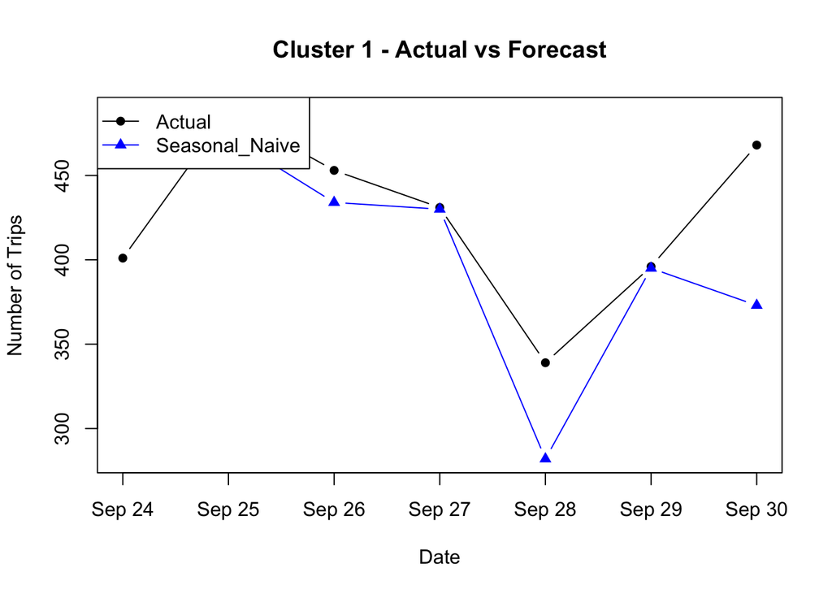

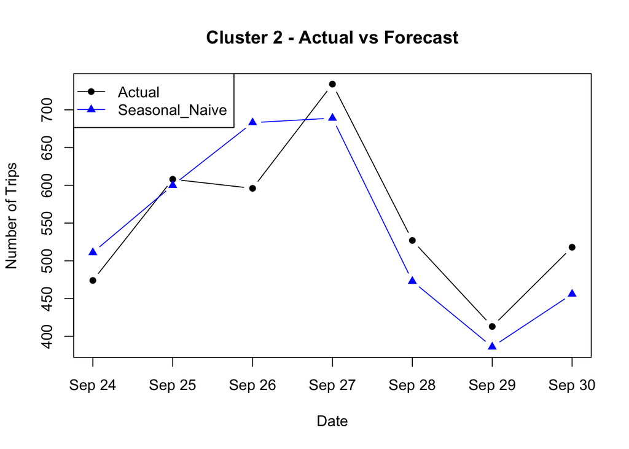

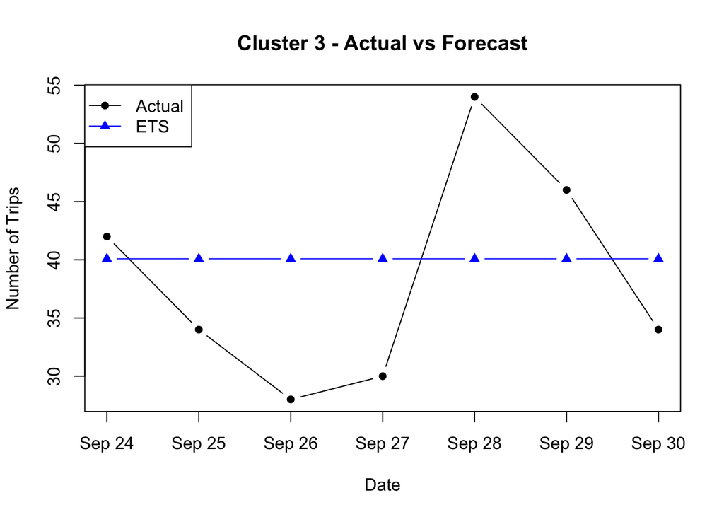

```r
# best model selected based on MAE results
best_models <- c(
  "Seasonal_Naive",
  "Seasonal_Naive",
  "ETS"
)

for (cl in 1:3) {

  p <- predictions[[cl]]
  model <- best_models[cl]

  # actual observation
  plot(
    p$Date, p$Actual,
    type = "b",
    pch = 16,
    col = "black",
    ylim = range(c(p$Actual, p[[model]])),
    xlab = "Date",
    ylab = "Number of Trips",
    main = paste("Cluster", cl, "- Actual vs Forecast")
  )

  # predicted observation
  lines(
    p$Date, p[[model]],
    type = "b",
    pch = 17,
    col = "blue"
  )

  legend(
    "topleft",
    legend = c("Actual", model),
    col = c("black", "blue"),
    pch = c(16, 17),
    lty = 1
  )
}
```

On those graph we can see how closely our model predict results vs actual one.

## ACF and PACF analysis

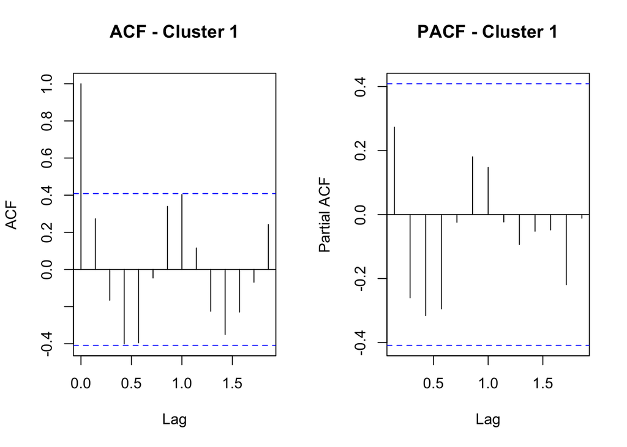

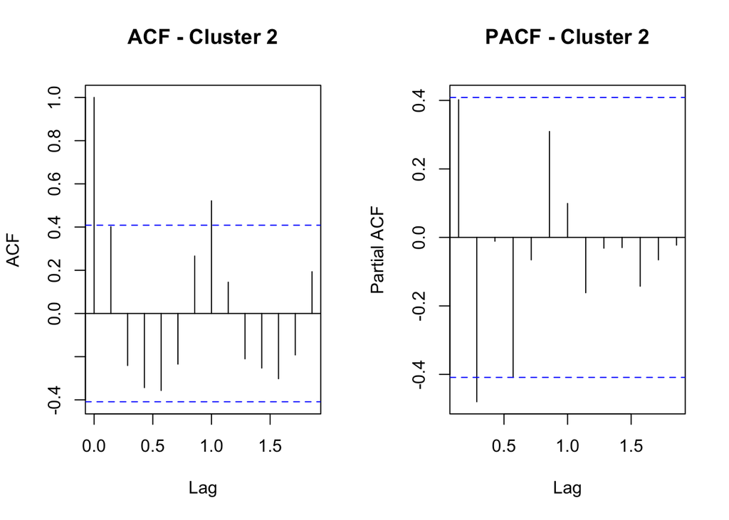

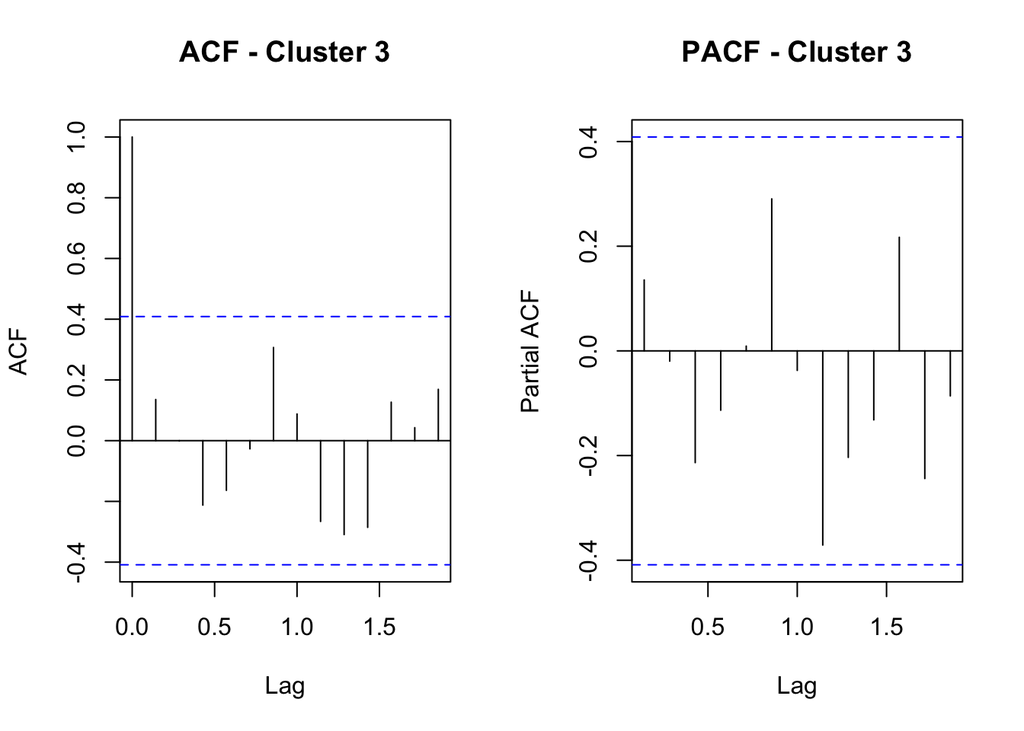

```r
for (cl in 1:3) {

  par(mfrow = c(1, 2))

  # autocorrelation function
  acf(
    trains[[cl]],
    main = paste("ACF - Cluster", cl)
  )

  # partial autocorrelation function
  pacf(
    trains[[cl]],
    main = paste("PACF - Cluster", cl)
  )
}
```

```r
par(mfrow = c(1, 1))
```

**Cluster 1:** The ACF shows a positive correlation at lag 7, suggesting possible weekly dependence, also the correlation doesn’t clearly exceed the significance boundary. The PACF doesn’t reveal a clear autoregressive structure.

**Cluster 2:** The ACF exhibits a significant positive spike at lag 7, suggesting a recurring weekly pattern. The PACF also shows a significant negative spike at lag 2. These observations indicate temporal dependence, consistent with the weekly activity peaks already look at it in the daily trip-count analysis.

**Cluster 3:** Neither ACF nor PACF reveals significant correlations at the examined nonzero lags. The absence of a clear weekly pattern suggests that simpler forecasting approaches may be appropriate.

The analysis provides stronger evidence of weekly dependence in Cluster 2 than in Clusters 1 and 3. Nevertheless, the limited number of training observations restricts the reliability of these findings.

## Inspect selecting forecast model

```r
# ARIMA models selected automatically
for (cl in 1:3) {

  cat("\nCluster", cl, "- ARIMA model\n")
  print(fits[[cl]]$ARIMA)
}
```

```
Cluster 1 - ARIMA model
Series: train
ARIMA(0,1,0)(1,1,0)[7]

Coefficients:
         sar1
      -0.5383
s.e.   0.2524

sigma^2 = 3651:  log likelihood = -83.49
AIC=170.97   AICc=171.97   BIC=172.39

Cluster 2 - ARIMA model
Series: train
ARIMA(0,1,0)(1,1,0)[7]

Coefficients:
         sar1
      -0.8248
s.e.   0.1179

sigma^2 = 2112:  log likelihood = -82.17
AIC=168.35   AICc=169.35   BIC=169.76

Cluster 3 - ARIMA model
Series: train
ARIMA(0,0,0) with non-zero mean

Coefficients:
         mean
      40.0870
s.e.   2.0309

sigma^2 = 99.17:  log likelihood = -84.99
AIC=173.98   AICc=174.58   BIC=176.25
```

```r
# ETS model for Cluster 3
summary(fits[[3]]$ETS)
```

```
ETS(A,N,N)

Call:
forecast::ets(y = train)

  Smoothing parameters:
    alpha = 1e-04

  Initial states:
    l = 40.0869

  sigma:  10.1935

     AIC     AICc      BIC
182.8244 184.0876 186.2309

Training set error measures:
                       ME   RMSE      MAE       MPE     MAPE      MASE
Training set -0.001340768 9.7402 8.439357 -6.287233 22.67688 0.8768163
                  ACF1
Training set 0.1355169
```

**Cluster 1 and 2:** - selected ARIMA(0,1,0)(1,1,0)[7] for both clusters. This model includes first-order and weekly seasonal differencing, as well as a seasonal autoregressive component. Although these models account for seasonal relationships, they produced larger forecasting errors than Seasonal Naive during the seven-day testing period.

**Cluster 3** - selected model was ARIMA(0,0,0) with a non-zero mean of approximately 40.09 trips per day. Similarly, ETS(A,N,N) identified no trend or seasonality, with a smoothing parameter of 0.0001 and an estimated level near 40.

## Residual diagnosis

```
Residual diagnostics - Cluster 1
```

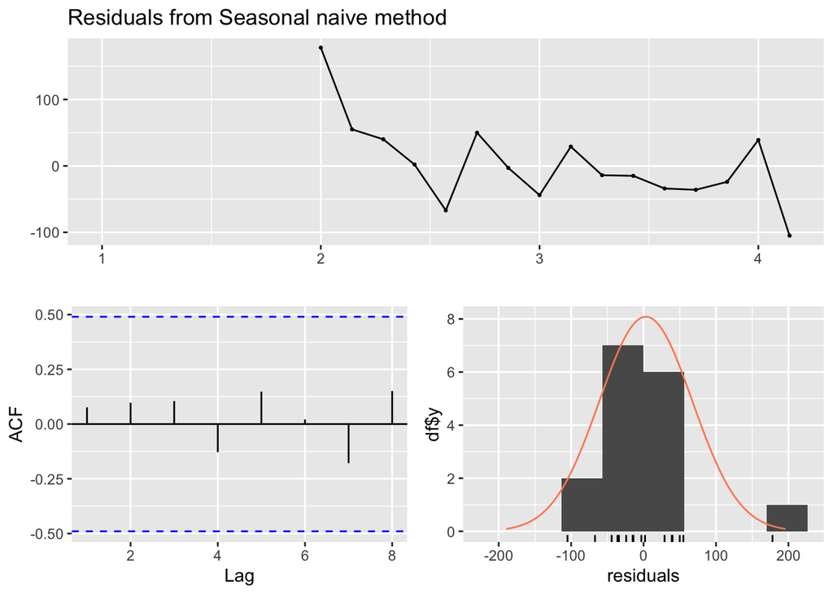

```
    Ljung-Box test

data:  Residuals from Seasonal naive method
Q* = 1.5205, df = 5, p-value = 0.9107

Model df: 0.   Total lags used: 5


Residual diagnostics - Cluster 2
```

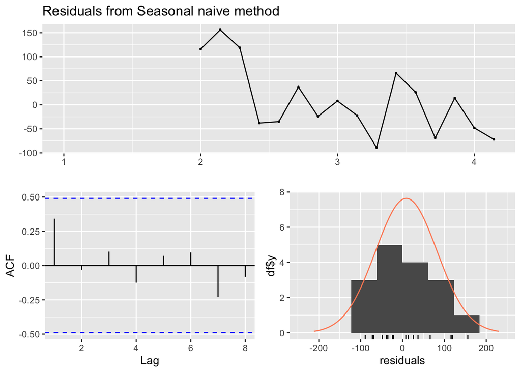

```
    Ljung-Box test

data:  Residuals from Seasonal naive method
Q* = 2.9949, df = 5, p-value = 0.7008

Model df: 0.   Total lags used: 5


Residual diagnostics - Cluster 3
```

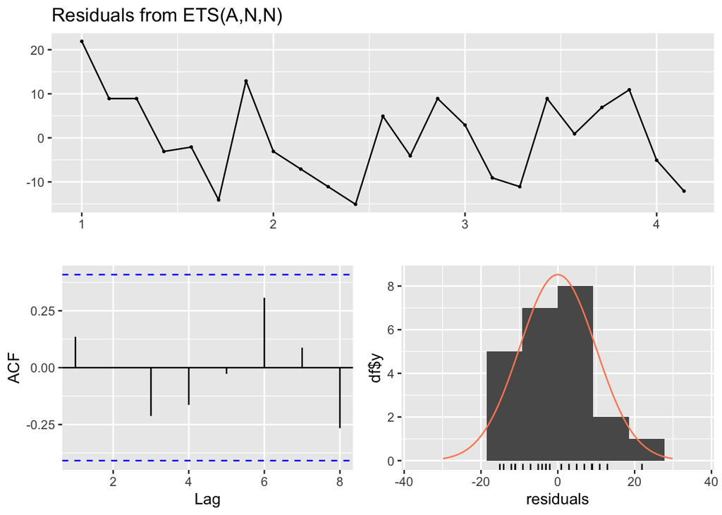

```
    Ljung-Box test

data:  Residuals from ETS(A,N,N)
Q* = 2.6097, df = 5, p-value = 0.7599

Model df: 0.   Total lags used: 5
```

```r
# check residuals of the selected models
for (cl in 1:3) {

  model <- fits[[cl]][[best_models[cl]]]

  cat("\nResidual diagnostics - Cluster", cl, "\n")

  checkresiduals(model)
}
```

```r
# Ljung-Box tests using 8 lags
for (cl in 1:3) {

  model <- fits[[cl]][[best_models[cl]]]
  errors <- na.omit(residuals(model))

  lb_test <- Box.test(
    errors,
    lag = 8,
    type = "Ljung-Box",
    fitdf = 0
  )

  cat(
    "Cluster", cl,
    "- Ljung-Box p-value:",
    round(lb_test$p.value, 4), "\n"
  )
}
```

```
Cluster 1 - Ljung-Box p-value: 0.9086
Cluster 2 - Ljung-Box p-value: 0.7367
Cluster 3 - Ljung-Box p-value: 0.3608
```

**Cluster 1:** The residuals fluctuate around zero, with some relatively large positive and negative errors. The residual ACF doesn’t reveal significant autocorrelation at the examined lags. The Ljung–Box test produced a p-value of 0.9086, indicating insufficient evidence to reject the null hypothesis of no residual autocorrelation.

**Cluster 2:** The residuals show noticeable fluctuations, including several large errors. However, the ACF doesn’t indicate statistically significant residual autocorrelation. The Ljung–Box p-value of 0.7367 also suggests no detectable autocorrelation at the tested lags.

**Cluster 3:** The ETS(A,N,N) residuals fluctuate around zero without a clear systematic pattern. No significant autocorrelation is observed in the residual ACF. The Ljung–Box test returned a p-value of 0.3608, providing insufficient evidence to reject the null hypothesis.